# **Traffic Sign Predictor**

```python
import warnings
warnings.filterwarnings("ignore")
import os
import kaggle
import pandas as pd
import numpy as np
import cv2
%matplotlib inline
import matplotlib.pyplot as plt
import seaborn as sns
import random
from sklearn.preprocessing import OneHotEncoder
from sklearn.model_selection import train_test_split
from sklearn.pipeline import Pipeline
from sklearn.compose import ColumnTransformer
from sklearn.preprocessing import FunctionTransformer
import tensorflow as tf
from tensorflow import keras
from keras.layers import Conv2D, MaxPooling2D, Flatten, Dense, Dropout, BatchNormalization, Input, LeakyReLU
from keras.models import Model
import time
from scikeras.wrappers import KerasRegressor
from keras.callbacks import ReduceLROnPlateau
from sklearn.model_selection import RandomizedSearchCV
from sklearn.metrics import accuracy_score, make_scorer
```

## **Import Data From Kaggle**

We are using the "GTSRB - German Traffic Sign Recognition Benchmark" dataset from "https://www.kaggle.com/datasets/meowmeowmeowmeowmeow/gtsrb-german-traffic-sign"

```python
kaggleDataset = "meowmeowmeowmeowmeow/gtsrb-german-traffic-sign"
datasetPath = os.path.join("dataset", "Traffic Signs")
```

```python
# Check if the dataset folder already exists
if os.path.exists(datasetPath):
    download = input("The dataset may already be downloaded. Do you want to download and replace it? (Y/N): ").strip().upper()
    if download == 'Y':
        kaggle.api.dataset_download_files(kaggleDataset, datasetPath, unzip=True)
        print("Dataset downloaded and unzipped.")
    else:
        print("Skipping download.")
else:
    # Download if the dataset folder doesn't exist
    kaggle.api.dataset_download_files(kaggleDataset, datasetPath, unzip=True)
    print("Dataset downloaded and unzipped.")
```

```
Skipping download.
```

## **Load Dataset CSV Files**

The dataset is already organized into three separate CSV files: Train, Test, and Meta. We define functions to load each of them into a pandas DataFrame for further processing.

```python
def loadTrafficSigns_Train(datasetPath = datasetPath):
    csvPath = os.path.join(datasetPath, "Train.csv")
    return pd.read_csv(csvPath, engine='python', on_bad_lines='skip')

def loadTrafficSigns_Test(datasetPath = datasetPath):
    csvPath = os.path.join(datasetPath, "Test.csv")
    return pd.read_csv(csvPath, engine='python', on_bad_lines='skip')

def loadTrafficSigns_Meta(datasetPath = datasetPath):
    csvPath = os.path.join(datasetPath, "Meta.csv")
    return pd.read_csv(csvPath, engine='python', on_bad_lines='skip')
```

```python
TrafficSigns_Train = loadTrafficSigns_Train()
TrafficSigns_Test = loadTrafficSigns_Test()
TrafficSigns_Meta = loadTrafficSigns_Meta()
```

## **Examine quick info about the data structure**

```python
TrafficSigns_Train.head()
```

|  | Width | Height | Roi.X1 | Roi.Y1 | Roi.X2 | Roi.Y2 | ClassId | Path |
| --- | --- | --- | --- | --- | --- | --- | --- | --- |
| 0 | 27 | 26 | 5 | 5 | 22 | 20 | 20 | Train/20/00020_00000_00000.png |
| 1 | 28 | 27 | 5 | 6 | 23 | 22 | 20 | Train/20/00020_00000_00001.png |
| 2 | 29 | 26 | 6 | 5 | 24 | 21 | 20 | Train/20/00020_00000_00002.png |
| 3 | 28 | 27 | 5 | 6 | 23 | 22 | 20 | Train/20/00020_00000_00003.png |
| 4 | 28 | 26 | 5 | 5 | 23 | 21 | 20 | Train/20/00020_00000_00004.png |

```python
TrafficSigns_Train.info()
```

```
<class 'pandas.core.frame.DataFrame'>
RangeIndex: 39209 entries, 0 to 39208
Data columns (total 8 columns):
 #   Column   Non-Null Count  Dtype
---  ------   --------------  -----
 0   Width    39209 non-null  int64
 1   Height   39209 non-null  int64
 2   Roi.X1   39209 non-null  int64
 3   Roi.Y1   39209 non-null  int64
 4   Roi.X2   39209 non-null  int64
 5   Roi.Y2   39209 non-null  int64
 6   ClassId  39209 non-null  int64
 7   Path     39209 non-null  object
dtypes: int64(7), object(1)
memory usage: 2.4+ MB
```

```python
TrafficSigns_Train.describe()
```

|  | Width | Height | Roi.X1 | Roi.Y1 | Roi.X2 | Roi.Y2 | ClassId |
| --- | --- | --- | --- | --- | --- | --- | --- |
| count | 39209.000000 | 39209.000000 | 39209.000000 | 39209.000000 | 39209.000000 | 39209.000000 | 39209.000000 |
| mean | 50.835880 | 50.328930 | 5.999515 | 5.962381 | 45.197302 | 44.728379 | 15.788390 |
| std | 24.306933 | 23.115423 | 1.475493 | 1.385440 | 23.060157 | 21.971145 | 12.013238 |
| min | 25.000000 | 25.000000 | 0.000000 | 5.000000 | 20.000000 | 20.000000 | 0.000000 |
| 25% | 35.000000 | 35.000000 | 5.000000 | 5.000000 | 29.000000 | 30.000000 | 5.000000 |
| 50% | 43.000000 | 43.000000 | 6.000000 | 6.000000 | 38.000000 | 38.000000 | 12.000000 |
| 75% | 58.000000 | 58.000000 | 6.000000 | 6.000000 | 53.000000 | 52.000000 | 25.000000 |
| max | 243.000000 | 225.000000 | 20.000000 | 20.000000 | 223.000000 | 205.000000 | 42.000000 |

We can create a dictionary mapping each ClassId to its image path using the metadata.

```python
class_mapping = {row["ClassId"]: row["Path"] for _, row in TrafficSigns_Meta.iterrows()}

print(class_mapping)
```

```
{27: 'Meta/27.png', 0: 'Meta/0.png', 1: 'Meta/1.png', 10: 'Meta/10.png', 11: 'Meta/11.png', 12: 'Meta/12.png', 13: 'Meta/13.png', 14: 'Meta/14.png', 15: 'Meta/15.png', 16: 'Meta/16.png', 17: 'Meta/17.png', 18: 'Meta/18.png', 19: 'Meta/19.png', 2: 'Meta/2.png', 20: 'Meta/20.png', 21: 'Meta/21.png', 2…
```

## **Visualize Sample Traffic Signs**

Displays a sample of traffic sign images from the metadata to get a quick visual reference of different classes.

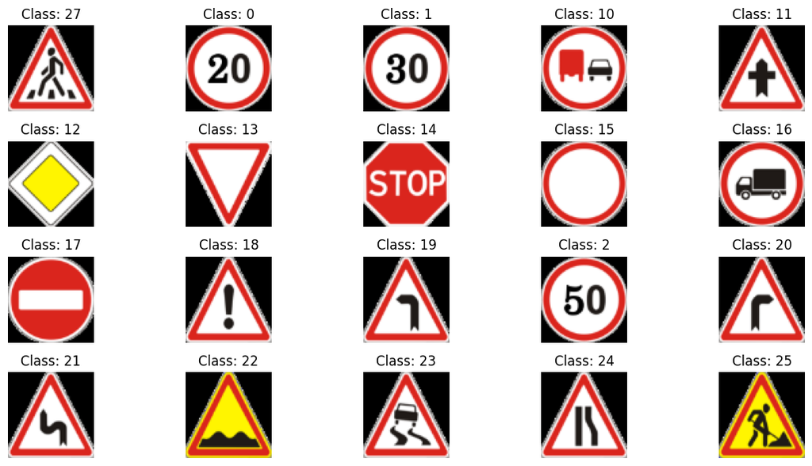

```python
def visualize_meta(class_mapping, datasetPath, num_classes=20):
    plt.figure(figsize=(12, 6))

    sampled_classes = list(class_mapping.keys())[:num_classes]
    for i, class_id in enumerate(sampled_classes):
        img_path = os.path.join(datasetPath, class_mapping[class_id])
        img = cv2.imread(img_path)
        img = cv2.resize(img, (64, 64))

        plt.subplot(4, 5, i + 1)
        plt.imshow(cv2.cvtColor(img, cv2.COLOR_BGR2RGB))
        plt.title(f"Class: {class_id}")
        plt.axis("off")

    plt.tight_layout()
    plt.show()

visualize_meta(class_mapping, datasetPath)
```

## **Load and Preprocess Training Images and Labels**

We load the training images and resize them to 64×64 pixels, normalizing pixel values to a 0–1 range. Labels are extracted as class IDs to be used for model training.

```python
def loadImages(df, dataset_path):
    images = []
    for _, row in df.iterrows():
        img_path = os.path.join(dataset_path, row["Path"])
        img = cv2.imread(img_path)
        img = cv2.resize(img, (64, 64))
        images.append(img)
    X = np.array(images).astype("float32") / 255.0
    return X
```

```python
train_images = loadImages(TrafficSigns_Train, datasetPath)
```

```python
def loadLabels(df, dataset_path):
    labels = []
    for _, row in df.iterrows():
        labels.append(row["ClassId"])
        y = np.array(labels)

    return y
```

```python
train_labels = loadLabels(TrafficSigns_Train, datasetPath)
```

```python
train_images[0]
```

```
array([[[0.21960784, 0.2       , 0.18039216],
        [0.21960784, 0.2       , 0.18039216],
        [0.21960784, 0.2       , 0.18431373],
        ...,
        [0.19607843, 0.19215687, 0.1882353 ],
        [0.19215687, 0.19215687, 0.18039216],
        [0.19215687, 0.19215687, 0.18039216]],

       [[0.21960784, 0.2       , 0.18039216],
        [0.21960784, 0.2       , 0.18039216],
        [0.21960784, 0.2       , 0.18431373],
        ...,
        [0.19607843, 0.19607843, 0.1882353 ],
        [0.19215687, 0.19215687, 0.18039216],
        [0.19215687, 0.19215687, 0.18039216]],

       [[0.21960784, 0.2       , 0.18039216],
        [0.21960784, 0.2       , 0.18039216],
        [0.21568628, 0.19607843, 0.18431373],
        ...,
        [0.2       , 0.20392157, 0.19607843],
        [0.19607843, 0.19607843, 0.18431373],
        [0.19215687, 0.19215687, 0.18039216]],

       ...,

       [[0.21568628, 0.20392157, 0.19607843],
        [0.21960784, 0.20784314, 0.19607843],
        [0.22745098, 0.21176471, 0.20392157],
        ...,
        [0.23921569, 0.34509805, 0.34509805],
        [0.23137255, 0.31764707, 0.30980393],
        [0.22745098, 0.30980393, 0.29803923]],

       [[0.21568628, 0.20392157, 0.2       ],
        [0.21960784, 0.20392157, 0.2       ],
        [0.22745098, 0.21176471, 0.20392157],
        ...,
        [0.23921569, 0.35686275, 0.3529412 ],
        [0.23921569, 0.33333334, 0.32156864],
        [0.23921569, 0.3254902 , 0.30980393]],

       [[0.21568628, 0.20392157, 0.2       ],
        [0.21960784, 0.20392157, 0.2       ],
        [0.22745098, 0.20784314, 0.20784314],
        ...,
        [0.23921569, 0.36078432, 0.3529412 ],
        [0.24313726, 0.3372549 , 0.32156864],
        [0.24313726, 0.33333334, 0.3137255 ]]], dtype=float32)
```

```python
print(f"Image shape: {train_images[0].shape}")
print(f"Pixel range: {train_images.min()} - {train_images.max()}")
```

```
Image shape: (64, 64, 3)
Pixel range: 0.0 - 1.0
```

## **Visualize Random Training Samples**

Displays random training images with their corresponding class labels to verify data loading and gain visual insight into the dataset.

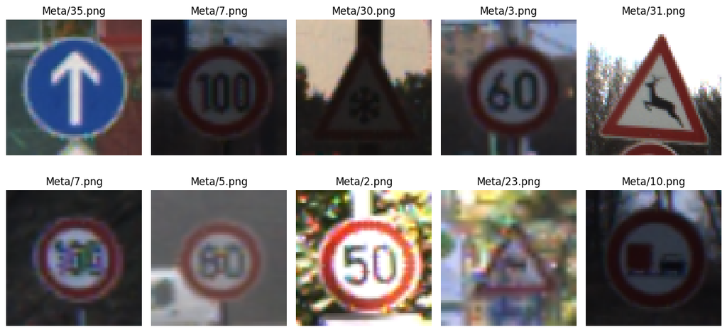

```python
def visualize_samples(X, y, class_mapping, num_samples=10):
    plt.figure(figsize=(12, 6))

    for i in range(num_samples):
        index = random.randint(0, len(X) - 1)
        plt.subplot(2, 5, i + 1)
        plt.imshow(cv2.cvtColor(X[index], cv2.COLOR_BGR2RGB))
        class_id = y[index]
        class_label = class_mapping.get(class_id, f"Class {class_id}")
        plt.title(f"{class_label}")
        plt.axis("off")

    plt.tight_layout()
    plt.show()

visualize_samples(train_images, train_labels, class_mapping)
```

## **Visualizing a Random Training Image as a Pixel-Intensity Heatmap**

Let’s visualize the raw pixel values of a randomly selected image from the training dataset. If the image is in color (3 channels), we’ll convert it to grayscale to simplify the visualization. Then, we’ll plot it using a heatmap where each cell shows the actual pixel intensity value.

This approach can help us better understand the structure and scaling of our input data, which is especially useful during the data exploration or preprocessing phase.

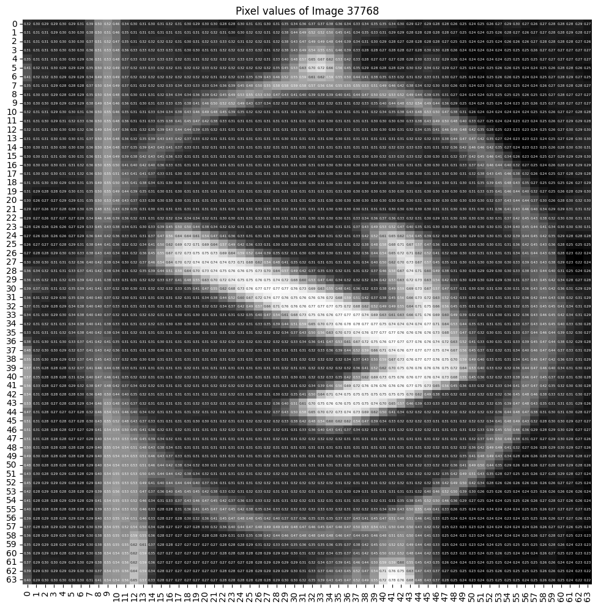

```python
index = random.randint(0, len(train_images) - 1)
image = train_images[index]

if image.shape[-1] == 3:
    image = cv2.cvtColor(image, cv2.COLOR_BGR2GRAY)

plt.figure(figsize=(12, 12))
sns.heatmap(image, cmap="gray", annot=True, fmt=".2f", cbar=False, annot_kws={"size": 4})
plt.title(f"Pixel values of Image {index}")
plt.show()
```

## **More Insightful Visualizations**

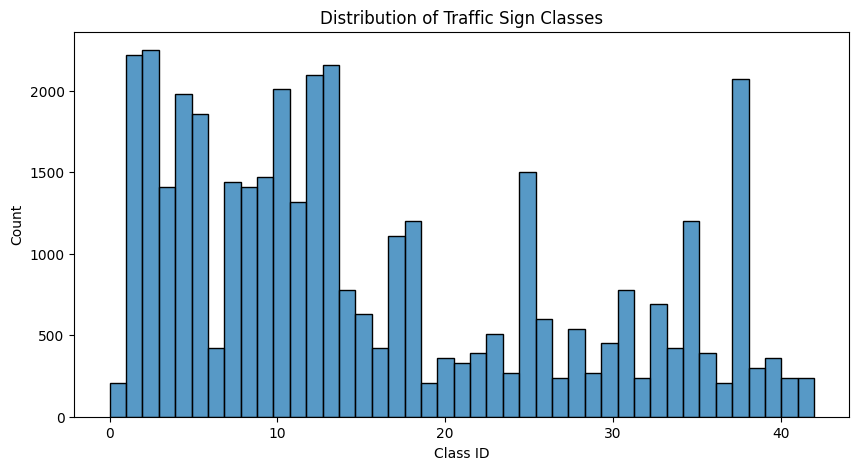

```python
plt.figure(figsize=(10,5))
sns.histplot(train_labels, bins=len(set(train_labels)), kde=False)
plt.xlabel("Class ID")
plt.ylabel("Count")
plt.title("Distribution of Traffic Sign Classes")
plt.show()
```

## **Encode Labels**

Reshapes the label array and applies one-hot encoding to prepare labels for training the neural network

```python
def reshapeLabels(y):
    return y.reshape(-1, 1)

y_train_reshaped = reshapeLabels(train_labels)

label_encoder = OneHotEncoder(sparse_output=False)

y_train_encoded = label_encoder.fit_transform(y_train_reshaped)

print(y_train_encoded[:5])
```

```
[[0. 0. 0. 0. 0. 0. 0. 0. 0. 0. 0. 0. 0. 0. 0. 0. 0. 0. 0. 0. 1. 0. 0. 0.
  0. 0. 0. 0. 0. 0. 0. 0. 0. 0. 0. 0. 0. 0. 0. 0. 0. 0. 0.]
 [0. 0. 0. 0. 0. 0. 0. 0. 0. 0. 0. 0. 0. 0. 0. 0. 0. 0. 0. 0. 1. 0. 0. 0.
  0. 0. 0. 0. 0. 0. 0. 0. 0. 0. 0. 0. 0. 0. 0. 0. 0. 0. 0.]
 [0. 0. 0. 0. 0. 0. 0. 0. 0. 0. 0. 0. 0. 0. 0. 0. 0. 0. 0. 0. 1. 0. 0. 0.
  0. 0. 0. 0. 0. 0. 0. 0. 0. 0. 0. 0. 0. 0. 0. 0. 0. 0. 0.]
 [0. 0. 0. 0. 0. 0. 0. 0. 0. 0. 0. 0. 0. 0. 0. 0. 0. 0. 0. 0. 1. 0. 0. 0.
  0. 0. 0. 0. 0. 0. 0. 0. 0. 0. 0. 0. 0. 0. 0. 0. 0. 0. 0.]
 [0. 0. 0. 0. 0. 0. 0. 0. 0. 0. 0. 0. 0. 0. 0. 0. 0. 0. 0. 0. 1. 0. 0. 0.
  0. 0. 0. 0. 0. 0. 0. 0. 0. 0. 0. 0. 0. 0. 0. 0. 0. 0. 0.]]
```

## **Preparing Training Data: Loading Images and Transforming Labels**

We start by loading the training images from the dataset using a custom loadImages() function. Next, we define a pipeline to process the image labels through three main stages:

Finally, we apply the pipeline to the training label set (TrafficSigns_Train) to generate the transformed label array y_train.

```python
X_train_prepared = loadImages(TrafficSigns_Train, datasetPath)
```

```python
label_pipeline = Pipeline([
    ("load_labels", FunctionTransformer(loadLabels, kw_args={"dataset_path": datasetPath})),
    ("reshape", FunctionTransformer(reshapeLabels)),
    ("onehot", label_encoder)
])

y_train = label_pipeline.fit_transform(TrafficSigns_Train)
```

```python
y_train[:5]
```

```
array([[0., 0., 0., 0., 0., 0., 0., 0., 0., 0., 0., 0., 0., 0., 0., 0.,
        0., 0., 0., 0., 1., 0., 0., 0., 0., 0., 0., 0., 0., 0., 0., 0.,
        0., 0., 0., 0., 0., 0., 0., 0., 0., 0., 0.],
       [0., 0., 0., 0., 0., 0., 0., 0., 0., 0., 0., 0., 0., 0., 0., 0.,
        0., 0., 0., 0., 1., 0., 0., 0., 0., 0., 0., 0., 0., 0., 0., 0.,
        0., 0., 0., 0., 0., 0., 0., 0., 0., 0., 0.],
       [0., 0., 0., 0., 0., 0., 0., 0., 0., 0., 0., 0., 0., 0., 0., 0.,
        0., 0., 0., 0., 1., 0., 0., 0., 0., 0., 0., 0., 0., 0., 0., 0.,
        0., 0., 0., 0., 0., 0., 0., 0., 0., 0., 0.],
       [0., 0., 0., 0., 0., 0., 0., 0., 0., 0., 0., 0., 0., 0., 0., 0.,
        0., 0., 0., 0., 1., 0., 0., 0., 0., 0., 0., 0., 0., 0., 0., 0.,
        0., 0., 0., 0., 0., 0., 0., 0., 0., 0., 0.],
       [0., 0., 0., 0., 0., 0., 0., 0., 0., 0., 0., 0., 0., 0., 0., 0.,
        0., 0., 0., 0., 1., 0., 0., 0., 0., 0., 0., 0., 0., 0., 0., 0.,
        0., 0., 0., 0., 0., 0., 0., 0., 0., 0., 0.]])
```

```python
X_train_prepared, X_val, y_train, y_val = train_test_split(X_train_prepared, y_train, test_size=0.2, random_state=42)
```

### **Model Architecture: Custom CNN with BatchNorm and Dropout**

We define a custom CNN using `keras.Model` for multi-class image classification (43 classes). The architecture includes:

- **4 Convolutional Blocks**: Each with Conv2D → optional BatchNormalization → MaxPooling.
- **Activation**: LeakyReLU (customizable slope).
- **Regularization**: Dropout in the dense layer to prevent overfitting.
- **Fully Connected Layers**: Flatten → Dense(256) → Dropout → Dense(43, softmax).

The model is flexible, allowing toggling of batch normalization, dropout rate, and LeakyReLU alpha. The `call()` method handles the forward pass, and `get_config()` allows easy saving and reuse.

```python
class CNNModel(keras.Model):
    def __init__(self, input_shape=(64, 64, 3), num_classes=43, add_batch_norm=1, dropout_rate=0.5, LeakyRLU_alpha=0.1, **kwargs):
        super().__init__(**kwargs)

        self.add_batch_norm = add_batch_norm
        self.LeakyRLU_alpha = LeakyRLU_alpha
        self.dropout_rate = dropout_rate
        self.activation_function = LeakyReLU(alpha=self.LeakyRLU_alpha)

        # Convolutional Base
        self.conv1 = Conv2D(32, (3, 3), activation=self.activation_function, padding='same', input_shape=input_shape)
        if self.add_batch_norm:
            self.bn1 = BatchNormalization()
        self.pool1 = MaxPooling2D((2, 2))

        self.conv2 = Conv2D(64, (3, 3), activation=self.activation_function, padding='same')
        if self.add_batch_norm:
            self.bn2 = BatchNormalization()
        self.pool2 = MaxPooling2D((2, 2))

        self.conv3 = Conv2D(128, (3, 3), activation=self.activation_function, padding='same')
        if self.add_batch_norm:
            self.bn3 = BatchNormalization()
        self.pool3 = MaxPooling2D((2, 2))

        self.conv4 = Conv2D(256, (3, 3), activation=self.activation_function, padding='same')
        if self.add_batch_norm:
            self.bn4 = BatchNormalization()
        self.pool4 = MaxPooling2D((2, 2))

        # Flatten and Fully Connected Layers
        self.flatten = Flatten()
        self.dense1 = Dense(256, activation=self.activation_function, kernel_initializer='he_normal')
        self.dropout = Dropout(dropout_rate)
        self.output_layer = Dense(num_classes, activation='softmax', name="target_type_output")

    def call(self, inputs):
        x = self.conv1(inputs)
        if self.add_batch_norm:
            x = self.bn1(x)
        x = self.pool1(x)

        x = self.conv2(x)
        if self.add_batch_norm:
            x = self.bn2(x)
        x = self.pool2(x)

        x = self.conv3(x)
        if self.add_batch_norm:
            x = self.bn3(x)
        x = self.pool3(x)

        x = self.conv4(x)
        if self.add_batch_norm:
            x = self.bn4(x)
        x = self.pool4(x)

        # Fully connected layer
        x = self.flatten(x)
        x = self.dense1(x)
        x = self.dropout(x)

        return self.output_layer(x)

    def get_config(self):
        config = super().get_config()
        config.update({
            "input_shape": (64, 64, 3),
            "num_classes": self.output_layer.units,
            "add_batch_norm": self.add_batch_norm,
            "dropout_rate": self.dropout_rate,
            "LeakyRLU_alpha": self.LeakyRLU_alpha
        })
        return config

    @property
    def outputs(self):
        return [self.output_layer]
```

```python
CNN_model = CNNModel(
    input_shape=(64, 64, 3),
    num_classes=43,
    add_batch_norm = 0,
    dropout_rate = 0.2,
    LeakyRLU_alpha=0.1
)
```

```python
CNN_model.compile(
    optimizer= keras.optimizers.Adam(learning_rate=0.001),
    loss='categorical_crossentropy',
    metrics=['accuracy']
)
```

```python
CNN_model.save("CNN_model.keras")
```

```python
CNN_model.summary()
```

```
Model: "cnn_model"
```

```
┏━━━━━━━━━━━━━━━━━━━━━━━━━━━━━━━━━┳━━━━━━━━━━━━━━━━━━━━━━━━┳━━━━━━━━━━━━━━━┓
┃ Layer (type)                    ┃ Output Shape           ┃       Param # ┃
┡━━━━━━━━━━━━━━━━━━━━━━━━━━━━━━━━━╇━━━━━━━━━━━━━━━━━━━━━━━━╇━━━━━━━━━━━━━━━┩
│ leaky_re_lu (LeakyReLU)         │ ?                      │             0 │
├─────────────────────────────────┼────────────────────────┼───────────────┤
│ conv2d (Conv2D)                 │ ?                      │   0 (unbuilt) │
├─────────────────────────────────┼────────────────────────┼───────────────┤
│ max_pooling2d (MaxPooling2D)    │ ?                      │             0 │
├─────────────────────────────────┼────────────────────────┼───────────────┤
│ conv2d_1 (Conv2D)               │ ?                      │   0 (unbuilt) │
├─────────────────────────────────┼────────────────────────┼───────────────┤
│ max_pooling2d_1 (MaxPooling2D)  │ ?                      │             0 │
├─────────────────────────────────┼────────────────────────┼───────────────┤
│ conv2d_2 (Conv2D)               │ ?                      │   0 (unbuilt) │
├─────────────────────────────────┼────────────────────────┼───────────────┤
│ max_pooling2d_2 (MaxPooling2D)  │ ?                      │             0 │
├─────────────────────────────────┼────────────────────────┼───────────────┤
│ conv2d_3 (Conv2D)               │ ?                      │   0 (unbuilt) │
├─────────────────────────────────┼────────────────────────┼───────────────┤
│ max_pooling2d_3 (MaxPooling2D)  │ ?                      │             0 │
├─────────────────────────────────┼────────────────────────┼───────────────┤
│ flatten (Flatten)               │ ?                      │   0 (unbuilt) │
├─────────────────────────────────┼────────────────────────┼───────────────┤
│ dense (Dense)                   │ ?                      │   0 (unbuilt) │
├─────────────────────────────────┼────────────────────────┼───────────────┤
│ dropout (Dropout)               │ ?                      │             0 │
├─────────────────────────────────┼────────────────────────┼───────────────┤
│ target_type_output (Dense)      │ ?                      │   0 (unbuilt) │
└─────────────────────────────────┴────────────────────────┴───────────────┘
```

```
 Total params: 0 (0.00 B)
```

```
 Trainable params: 0 (0.00 B)
```

```
 Non-trainable params: 0 (0.00 B)
```

```python
CNN_model.layers
```

```
[<LeakyReLU name=leaky_re_lu, built=True>,
 <Conv2D name=conv2d, built=False>,
 <MaxPooling2D name=max_pooling2d, built=True>,
 <Conv2D name=conv2d_1, built=False>,
 <MaxPooling2D name=max_pooling2d_1, built=True>,
 <Conv2D name=conv2d_2, built=False>,
 <MaxPooling2D name=max_pooling2d_2, built=True>,
 <Conv2D name=conv2d_3, built=False>,
 <MaxPooling2D name=max_pooling2d_3, built=True>,
 <Flatten name=flatten, built=False>,
 <Dense name=dense, built=False>,
 <Dropout name=dropout, built=True>,
 <Dense name=target_type_output, built=False>]
```

## **Set Up TensorBoard Logging**

Prepares a logging directory with a unique timestamped folder to store training logs for TensorBoard visualization later in the script.

```python
root_logdir = os.path.join(os.curdir, "Logs", "CNN Model")

def get_run_logdir():
    run_id = time.strftime("run_%Y_%m_%d-%H_%M_%S")

    return os.path.join(root_logdir, run_id)

run_logdir = get_run_logdir()

os.makedirs(run_logdir, exist_ok=True)
```

## **Training with Callbacks**

We train the model with callbacks to boost performance:

- **Checkpoint**: Saves the best model.
- **EarlyStopping**: Stops early if no improvement.
- **TensorBoard**: Tracks training progress.
- **ReduceLROnPlateau**: Lowers learning rate on plateaus.

Training runs for up to 200 epochs with validation.

```python
checkpoint_cb = keras.callbacks.ModelCheckpoint("CNN_model.keras", save_best_only=True)
early_stopping_cb = keras.callbacks.EarlyStopping(monitor='val_loss', patience=7, restore_best_weights=True)
tensorboard_cb = keras.callbacks.TensorBoard(run_logdir)
reduce_lr = ReduceLROnPlateau(monitor="val_loss", factor=0.5, patience=5, min_lr=1e-5)


history = CNN_model.fit(
    X_train_prepared,
    y_train,
    epochs=200,
    validation_data=(
        X_val,
        y_val
    ),
    callbacks=[checkpoint_cb, early_stopping_cb, tensorboard_cb, reduce_lr]
)
```

```
981/981 ━━━━━━━━━━━━━━━━━━━━ 56s 56ms/step - accuracy: 0.4733 - loss: 1.8688 - val_accuracy: 0.9719 - val_loss: 0.0880 - learning_rate: 0.0010
981/981 ━━━━━━━━━━━━━━━━━━━━ 50s 51ms/step - accuracy: 0.9813 - loss: 0.0624 - val_accuracy: 0.9786 - val_loss: 0.0821 - learning_rate: 0.0010
981/981 ━━━━━━━━━━━━━━━━━━━━ 52s 53ms/step - accuracy: 0.9905 - loss: 0.0335 - val_accuracy: 0.9782 - val_loss: 0.0944 - learning_rate: 0.0010
981/981 ━━━━━━━━━━━━━━━━━━━━ 51s 52ms/step - accuracy: 0.9940 - loss: 0.0202 - val_accuracy: 0.9830 - val_loss: 0.0634 - learning_rate: 0.0010
981/981 ━━━━━━━━━━━━━━━━━━━━ 52s 53ms/step - accuracy: 0.9902 - loss: 0.0373 - val_accuracy: 0.9889 - val_loss: 0.0419 - learning_rate: 0.0010
981/981 ━━━━━━━━━━━━━━━━━━━━ 51s 52ms/step - accuracy: 0.9937 - loss: 0.0257 - val_accuracy: 0.9861 - val_loss: 0.0797 - learning_rate: 0.0010
981/981 ━━━━━━━━━━━━━━━━━━━━ 52s 53ms/step - accuracy: 0.9930 - loss: 0.0275 - val_accuracy: 0.9959 - val_loss: 0.0230 - learning_rate: 0.0010
981/981 ━━━━━━━━━━━━━━━━━━━━ 51s 52ms/step - accuracy: 0.9959 - loss: 0.0181 - val_accuracy: 0.9838 - val_loss: 0.0711 - learning_rate: 0.0010
981/981 ━━━━━━━━━━━━━━━━━━━━ 49s 50ms/step - accuracy: 0.9970 - loss: 0.0106 - val_accuracy: 0.9888 - val_loss: 0.0457 - learning_rate: 0.0010
981/981 ━━━━━━━━━━━━━━━━━━━━ 51s 52ms/step - accuracy: 0.9952 - loss: 0.0265 - val_accuracy: 0.9948 - val_loss: 0.0345 - learning_rate: 0.0010
981/981 ━━━━━━━━━━━━━━━━━━━━ 52s 53ms/step - accuracy: 0.9948 - loss: 0.0281 - val_accuracy: 0.9874 - val_loss: 0.0731 - learning_rate: 0.0010
981/981 ━━━━━━━━━━━━━━━━━━━━ 52s 53ms/step - accuracy: 0.9965 - loss: 0.0176 - val_accuracy: 0.9926 - val_loss: 0.0648 - learning_rate: 0.0010
981/981 ━━━━━━━━━━━━━━━━━━━━ 52s 53ms/step - accuracy: 0.9982 - loss: 0.0059 - val_accuracy: 0.9966 - val_loss: 0.0285 - learning_rate: 5.0000e-04
981/981 ━━━━━━━━━━━━━━━━━━━━ 52s 53ms/step - accuracy: 0.9998 - loss: 9.6282e-04 - val_accuracy: 0.9922 - val_loss: 0.0487 - learning_rate: 5.0000e-04
```

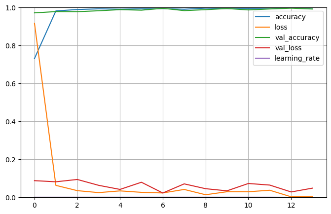

```python
pd.DataFrame(history.history).plot(figsize=(8,5))
plt.grid(True)
plt.gca().set_ylim(0, 1)
plt.show()
```

```python
CNN_model = keras.models.load_model("CNN_model.keras", custom_objects={"CNNModel": CNNModel, "LeakyReLU": LeakyReLU})
```

```python
X_test_prepared = loadImages(TrafficSigns_Test, datasetPath)
y_test = label_pipeline.fit_transform(TrafficSigns_Test)
```

```python
total_loss, total_accuracy = CNN_model.evaluate(
    X_test_prepared,
    y_test
)

print(f"Total Loss: {total_loss}")
print(f"Total Accuracy: {total_accuracy}")
```

```
395/395 ━━━━━━━━━━━━━━━━━━━━ 6s 15ms/step - accuracy: 0.9648 - loss: 0.2240
Total Loss: 0.2086896300315857
Total Accuracy: 0.96856689453125
```

## **Fine-Tuning Our Model: Hyperparameter Optimization**

To fine-tune our model, we'll use SciKeras' `KerasRegressor` to wrap our model, enabling us to use it as an estimator for hyperparameter optimization with `RandomizedSearchCV`.

When using SciKeras, it's important to prefix model parameters with `model__` in the `param_distribs` dictionary. This ensures that `RandomizedSearchCV` correctly identifies them as arguments for the `build_CNN_model()` function.

```python
def build_CNN_model(input_shape=(64, 64, 3), num_classes=43, add_batch_norm=1, dropout_rate=0.5, LeakyRLU_alpha=0.1, learning_rate=0.001):
    model = CNNModel(input_shape=input_shape,
                     num_classes=num_classes,
                     add_batch_norm=add_batch_norm,
                     dropout_rate=dropout_rate,
                     LeakyRLU_alpha=LeakyRLU_alpha)

    model.compile(optimizer= keras.optimizers.Adam(learning_rate=learning_rate),
                  loss="categorical_crossentropy",
                  metrics=["accuracy"])

    return model
```

```python
keras_reg = KerasRegressor(model=build_CNN_model, epochs=50, batch_size=32, verbose=1)
```

```python
param_distribs = {
    "model__add_batch_norm": [0, 1],
    "model__dropout_rate": [0.1, 0.3, 0.5, 0.7],
    "model__LeakyRLU_alpha": [0.1, 0.2, 0.3],
    "model__learning_rate": [0.0001, 0.001, 0.01]
}

def onehot_accuracy(y_true, y_pred):
    y_true_labels = np.argmax(y_true, axis=1)
    y_pred_labels = np.argmax(y_pred, axis=1)
    return accuracy_score(y_true_labels, y_pred_labels)

custom_scorer = make_scorer(onehot_accuracy)

rnd_search_cv = RandomizedSearchCV(
    estimator=keras_reg,
    param_distributions=param_distribs,
    n_iter=5,
    cv=3,
    scoring=custom_scorer,
    verbose=1,
    n_jobs=-3,
    refit=False
)
```

```python
X_train_small = X_train_prepared[:5000]
y_train_small = y_train[:5000]
X_val_small = X_val[:1000]
y_val_small = y_val[:1000]
```

```python
early_stopping_cb = keras.callbacks.EarlyStopping(monitor='val_loss', patience=3, restore_best_weights=True)
reduce_lr = ReduceLROnPlateau(monitor="val_loss", factor=0.5, patience=5, min_lr=1e-5)

rnd_search_cv.fit(
    X_train_small,
    y_train_small,
    validation_data=(
        X_val_small,
        y_val_small
    ),
    callbacks=[early_stopping_cb, reduce_lr]
)
```

```
Fitting 3 folds for each of 5 candidates, totalling 15 fits
```

[output not shown]

[output not shown]

[output cut: 385 more lines]

```
105/105 ━━━━━━━━━━━━━━━━━━━━ 48s 455ms/step - accuracy: 0.9974 - loss: 0.0072 - val_accuracy: 0.8360 - val_loss: 0.9120
105/105 ━━━━━━━━━━━━━━━━━━━━ 48s 455ms/step - accuracy: 1.0000 - loss: 0.0014 - val_accuracy: 0.8860 - val_loss: 0.6955
105/105 ━━━━━━━━━━━━━━━━━━━━ 89s 483ms/step - accuracy: 1.0000 - loss: 1.0389e-05 - val_accuracy: 0.9630 - val_loss: 0.3646
105/105 ━━━━━━━━━━━━━━━━━━━━ 49s 466ms/step - accuracy: 0.9235 - loss: 2.7010 - val_accuracy: 0.8920 - val_loss: 5.1595
105/105 ━━━━━━━━━━━━━━━━━━━━ 50s 479ms/step - accuracy: 1.0000 - loss: 9.3436e-06 - val_accuracy: 0.9640 - val_loss: 0.2354
105/105 ━━━━━━━━━━━━━━━━━━━━ 46s 441ms/step - accuracy: 0.9759 - loss: 0.1262 - val_accuracy: 0.9010 - val_loss: 1.2451
105/105 ━━━━━━━━━━━━━━━━━━━━ 46s 442ms/step - accuracy: 1.0000 - loss: 1.0601e-05 - val_accuracy: 0.9650 - val_loss: 0.1574
105/105 ━━━━━━━━━━━━━━━━━━━━ 45s 429ms/step - accuracy: 0.9814 - loss: 0.1433 - val_accuracy: 0.8930 - val_loss: 3.0430
105/105 ━━━━━━━━━━━━━━━━━━━━ 43s 407ms/step - accuracy: 1.0000 - loss: 0.0042 - val_accuracy: 0.9010 - val_loss: 0.6430
105/105 ━━━━━━━━━━━━━━━━━━━━ 44s 418ms/step - accuracy: 0.9517 - loss: 0.2251 - val_accuracy: 0.8430 - val_loss: 0.6320
105/105 ━━━━━━━━━━━━━━━━━━━━ 43s 411ms/step - accuracy: 1.0000 - loss: 0.0012 - val_accuracy: 0.8870 - val_loss: 0.7048
105/105 ━━━━━━━━━━━━━━━━━━━━ 44s 421ms/step - accuracy: 1.0000 - loss: 1.1095e-05 - val_accuracy: 0.9630 - val_loss: 0.3670
105/105 ━━━━━━━━━━━━━━━━━━━━ 43s 406ms/step - accuracy: 0.9660 - loss: 0.7217 - val_accuracy: 0.9110 - val_loss: 4.3886
53/53 ━━━━━━━━━━━━━━━━━━━━ 7s 125ms/steptep - accuracy: 1.0000 - loss: 7.2033e-0
100/105 ━━━━━━━━━━━━━━━━━━━━ 1s 399ms/step - accuracy: 0.9810 - loss: 0.2261e-00
```

```
 65/105 ━━━━━━━━━━━━━━━━━━━━ 16s 422ms/step - accuracy: 1.0000 - loss: 0.0013e-0Epoch 1/50
105/105 ━━━━━━━━━━━━━━━━━━━━ 44s 424ms/step - accuracy: 0.9816 - loss: 0.0995 - val_accuracy: 0.8980 - val_loss: 1.2579
105/105 ━━━━━━━━━━━━━━━━━━━━ 45s 433ms/step - accuracy: 0.9807 - loss: 0.2312 - val_accuracy: 0.8880 - val_loss: 2.7151
105/105 ━━━━━━━━━━━━━━━━━━━━ 46s 440ms/step - accuracy: 1.0000 - loss: 8.8603e-06 - val_accuracy: 0.9660 - val_loss: 0.1578
105/105 ━━━━━━━━━━━━━━━━━━━━ 47s 447ms/step - accuracy: 1.0000 - loss: 0.0032 - val_accuracy: 0.9000 - val_loss: 0.6723
105/105 ━━━━━━━━━━━━━━━━━━━━ 48s 459ms/step - accuracy: 0.9830 - loss: 0.0723 - val_accuracy: 0.8540 - val_loss: 0.7224
105/105 ━━━━━━━━━━━━━━━━━━━━ 47s 454ms/step - accuracy: 1.0000 - loss: 0.0012 - val_accuracy: 0.8880 - val_loss: 0.7112
53/53 ━━━━━━━━━━━━━━━━━━━━ 7s 123ms/stepep - accuracy: 1.0000 - loss: 7.9284e-
53/53 ━━━━━━━━━━━━━━━━━━━━ 7s 115ms/steptep - accuracy: 0.9708 - loss: 0.2976e-
 57/105 ━━━━━━━━━━━━━━━━━━━━ 18s 392ms/step - accuracy: 0.9708 - loss: 0.2952-0
```

```
 72/105 ━━━━━━━━━━━━━━━━━━━━ 13s 394ms/step - accuracy: 0.9375 - loss: 0.6152--0
```

```
105/105 ━━━━━━━━━━━━━━━━━━━━ 78s 447ms/step - accuracy: 1.0000 - loss: 7.9344e-06 - val_accuracy: 0.9640 - val_loss: 0.2367
105/105 ━━━━━━━━━━━━━━━━━━━━ 44s 422ms/step - accuracy: 1.0000 - loss: 1.1014e-05 - val_accuracy: 0.9630 - val_loss: 0.3683
105/105 ━━━━━━━━━━━━━━━━━━━━ 44s 416ms/step - accuracy: 0.9357 - loss: 0.6116 - val_accuracy: 0.8990 - val_loss: 1.2242
105/105 ━━━━━━━━━━━━━━━━━━━━ 44s 414ms/step - accuracy: 0.9703 - loss: 0.3101 - val_accuracy: 0.9020 - val_loss: 2.9664
105/105 ━━━━━━━━━━━━━━━━━━━━ 45s 432ms/step - accuracy: 1.0000 - loss: 8.3081e-06 - val_accuracy: 0.9660 - val_loss: 0.1583
53/53 ━━━━━━━━━━━━━━━━━━━━ 8s 140ms/steptep - accuracy: 0.0318 - loss: 26.219
105/105 ━━━━━━━━━━━━━━━━━━━━ 53s 415ms/step - accuracy: 0.0463 - loss: 24.5301 - val_accuracy: 0.0850 - val_loss: 3.5120
 63/105 ━━━━━━━━━━━━━━━━━━━━ 17s 405ms/step - accuracy: 1.0000 - loss: 9.7227e-06
```

```
23/53 ━━━━━━━━━━━━━━━━━━━━ 3s 124ms/stepEpoch 1/50
105/105 ━━━━━━━━━━━━━━━━━━━━ 43s 409ms/step - accuracy: 1.0000 - loss: 0.0032 - val_accuracy: 0.8980 - val_loss: 0.6782
53/53 ━━━━━━━━━━━━━━━━━━━━ 8s 134ms/steptep - accuracy: 1.0000 - loss: 9.5758e-
53/53 ━━━━━━━━━━━━━━━━━━━━ 7s 115ms/steptep - accuracy: 0.0858 - loss: 3.4993e-0
 60/105 ━━━━━━━━━━━━━━━━━━━━ 17s 390ms/step - accuracy: 1.0000 - loss: 1.1373e-05
```

```
32/53 ━━━━━━━━━━━━━━━━━━━━ 2s 98ms/stepEpoch 1/50uracy: 0.0325 - loss: 20.914e-
 59/105 ━━━━━━━━━━━━━━━━━━━━ 17s 387ms/step - accuracy: 0.0351 - loss: 53.0435-0
```

[output not shown]

[output cut: 265 more lines]

```
105/105 ━━━━━━━━━━━━━━━━━━━━ 25s 242ms/step - accuracy: 1.0000 - loss: 6.7392e-06 - val_accuracy: 0.9450 - val_loss: 0.4352
105/105 ━━━━━━━━━━━━━━━━━━━━ 26s 249ms/step - accuracy: 0.0887 - loss: 8.1298 - val_accuracy: 0.0850 - val_loss: 8.5732
53/53 ━━━━━━━━━━━━━━━━━━━━ 4s 63ms/steptep - accuracy: 0.9033 - loss: 1.35471e-0
53/53 ━━━━━━━━━━━━━━━━━━━━ 4s 62ms/stepstep - accuracy: 1.0000 - loss: 5.8021e-0
105/105 ━━━━━━━━━━━━━━━━━━━━ 25s 240ms/step - accuracy: 0.9057 - loss: 1.3224 - val_accuracy: 0.8350 - val_loss: 6.6292
105/105 ━━━━━━━━━━━━━━━━━━━━ 20s 192ms/step - accuracy: 1.0000 - loss: 6.5549e-06 - val_accuracy: 0.9420 - val_loss: 0.4126
105/105 ━━━━━━━━━━━━━━━━━━━━ 21s 197ms/step - accuracy: 0.9331 - loss: 0.2489 - val_accuracy: 0.7970 - val_loss: 1.6968
53/53 ━━━━━━━━━━━━━━━━━━━━ 2s 44ms/steptep - accuracy: 1.0000 - loss: 5.9658e-0
105/105 ━━━━━━━━━━━━━━━━━━━━ 18s 168ms/step - accuracy: 1.0000 - loss: 5.9829e-06 - val_accuracy: 0.9470 - val_loss: 0.4360
53/53 ━━━━━━━━━━━━━━━━━━━━ 2s 36ms/steptep - accuracy: 0.9304 - loss: 0.237
105/105 ━━━━━━━━━━━━━━━━━━━━ 15s 146ms/step - accuracy: 0.9280 - loss: 0.9339 - val_accuracy: 0.7820 - val_loss: 5.0880
53/53 ━━━━━━━━━━━━━━━━━━━━ 2s 29ms/steptep - accuracy: 0.9273 - loss: 0.283
105/105 ━━━━━━━━━━━━━━━━━━━━ 10s 98ms/step - accuracy: 0.9249 - loss: 0.3005 - val_accuracy: 0.7720 - val_loss: 1.8957
105/105 ━━━━━━━━━━━━━━━━━━━━ 6s 60ms/step - accuracy: 0.8605 - loss: 0.9796 - val_accuracy: 0.6240 - val_loss: 3.8210
53/53 ━━━━━━━━━━━━━━━━━━━━ 1s 17ms/step
```

```
RandomizedSearchCV(cv=3,
                   estimator=KerasRegressor(batch_size=32, epochs=50, model=<function build_CNN_model at 0x32f2e80e0>),
                   n_iter=5, n_jobs=-3,
                   param_distributions={'model__LeakyRLU_alpha': [0.1, 0.2,
                                                                  0.3],
                                        'model__add_batch_norm': [0, 1],
                                        'model__dropout_rate': [0.1, 0.3, 0.5,
                                                                0.7],
                                        'model__learning_rate': [0.0001, 0.001,
                                                                 0.01]},
                   refit=False,
                   scoring=make_scorer(onehot_accuracy, response_method='predict'),
                   verbose=1)
```

```python
rnd_search_cv.best_params_
```

```
{'model__learning_rate': 0.001,
 'model__dropout_rate': 0.7,
 'model__add_batch_norm': 1,
 'model__LeakyRLU_alpha': 0.3}
```

## **Build, Compile, and Save Final Model**

Using the best hyperparameters from randomized search, we construct, compile, and save the final CNN model for deployment or further evaluation.

```python
best_params = rnd_search_cv.best_params_

final_model = CNNModel(
    add_batch_norm=best_params['model__add_batch_norm'],
    dropout_rate=best_params['model__dropout_rate'],
    LeakyRLU_alpha=best_params['model__LeakyRLU_alpha']
)

final_model.compile(
    optimizer=keras.optimizers.Adam(learning_rate=best_params['model__learning_rate']),
    loss='categorical_crossentropy',
    metrics=['accuracy']
)

final_model.save("CNN_model_final.keras")
```

```python
root_logdir = os.path.join(os.curdir, "Logs", "Final Model")

def get_run_logdir():
    run_id = time.strftime("run_%Y_%m_%d-%H_%M_%S")

    return os.path.join(root_logdir, run_id)

run_logdir = get_run_logdir()

os.makedirs(run_logdir, exist_ok=True)
```

```python
checkpoint_cb = keras.callbacks.ModelCheckpoint("CNN_model_final.keras", save_best_only=True)
early_stopping_cb = keras.callbacks.EarlyStopping(monitor='val_loss', patience=7, restore_best_weights=True)
tensorboard_cb = keras.callbacks.TensorBoard(run_logdir)
reduce_lr = ReduceLROnPlateau(monitor="val_loss", factor=0.5, patience=5, min_lr=1e-5)


history = final_model.fit(
    X_train_prepared,
    y_train,
    epochs=200,
    validation_data=(
        X_val,
        y_val
    ),
    callbacks=[checkpoint_cb, early_stopping_cb, tensorboard_cb, reduce_lr]
)
```

```
981/981 ━━━━━━━━━━━━━━━━━━━━ 61s 60ms/step - accuracy: 0.5857 - loss: 1.4537 - val_accuracy: 0.9824 - val_loss: 0.0590 - learning_rate: 0.0010
981/981 ━━━━━━━━━━━━━━━━━━━━ 59s 60ms/step - accuracy: 0.9818 - loss: 0.0613 - val_accuracy: 0.9814 - val_loss: 0.1213 - learning_rate: 0.0010
981/981 ━━━━━━━━━━━━━━━━━━━━ 56s 58ms/step - accuracy: 0.9896 - loss: 0.0442 - val_accuracy: 0.9874 - val_loss: 0.0568 - learning_rate: 0.0010
981/981 ━━━━━━━━━━━━━━━━━━━━ 57s 59ms/step - accuracy: 0.9896 - loss: 0.0402 - val_accuracy: 0.9889 - val_loss: 0.0375 - learning_rate: 0.0010
981/981 ━━━━━━━━━━━━━━━━━━━━ 57s 58ms/step - accuracy: 0.9907 - loss: 0.0391 - val_accuracy: 0.9946 - val_loss: 0.0271 - learning_rate: 0.0010
981/981 ━━━━━━━━━━━━━━━━━━━━ 58s 59ms/step - accuracy: 0.9951 - loss: 0.0261 - val_accuracy: 0.9926 - val_loss: 0.0312 - learning_rate: 0.0010
981/981 ━━━━━━━━━━━━━━━━━━━━ 58s 60ms/step - accuracy: 0.9916 - loss: 0.0446 - val_accuracy: 0.9915 - val_loss: 0.0406 - learning_rate: 0.0010
981/981 ━━━━━━━━━━━━━━━━━━━━ 57s 58ms/step - accuracy: 0.9972 - loss: 0.0134 - val_accuracy: 0.9733 - val_loss: 0.1784 - learning_rate: 0.0010
981/981 ━━━━━━━━━━━━━━━━━━━━ 58s 59ms/step - accuracy: 0.9924 - loss: 0.0496 - val_accuracy: 0.9948 - val_loss: 0.0269 - learning_rate: 0.0010
981/981 ━━━━━━━━━━━━━━━━━━━━ 58s 59ms/step - accuracy: 0.9952 - loss: 0.0226 - val_accuracy: 0.9907 - val_loss: 0.0493 - learning_rate: 0.0010
981/981 ━━━━━━━━━━━━━━━━━━━━ 58s 59ms/step - accuracy: 0.9946 - loss: 0.0352 - val_accuracy: 0.9815 - val_loss: 0.1743 - learning_rate: 0.0010
981/981 ━━━━━━━━━━━━━━━━━━━━ 58s 59ms/step - accuracy: 0.9947 - loss: 0.0444 - val_accuracy: 0.9955 - val_loss: 0.0303 - learning_rate: 0.0010
981/981 ━━━━━━━━━━━━━━━━━━━━ 58s 59ms/step - accuracy: 0.9987 - loss: 0.0058 - val_accuracy: 0.9851 - val_loss: 0.1508 - learning_rate: 0.0010
981/981 ━━━━━━━━━━━━━━━━━━━━ 58s 59ms/step - accuracy: 0.9911 - loss: 0.0634 - val_accuracy: 0.9955 - val_loss: 0.0425 - learning_rate: 0.0010
981/981 ━━━━━━━━━━━━━━━━━━━━ 58s 60ms/step - accuracy: 0.9993 - loss: 0.0024 - val_accuracy: 0.9971 - val_loss: 0.0253 - learning_rate: 5.0000e-04
981/981 ━━━━━━━━━━━━━━━━━━━━ 58s 59ms/step - accuracy: 0.9999 - loss: 3.2034e-04 - val_accuracy: 0.9971 - val_loss: 0.0248 - learning_rate: 5.0000e-04
981/981 ━━━━━━━━━━━━━━━━━━━━ 58s 59ms/step - accuracy: 1.0000 - loss: 1.4257e-05 - val_accuracy: 0.9969 - val_loss: 0.0248 - learning_rate: 5.0000e-04
981/981 ━━━━━━━━━━━━━━━━━━━━ 58s 59ms/step - accuracy: 1.0000 - loss: 5.6332e-06 - val_accuracy: 0.9971 - val_loss: 0.0246 - learning_rate: 5.0000e-04
981/981 ━━━━━━━━━━━━━━━━━━━━ 59s 60ms/step - accuracy: 1.0000 - loss: 4.3263e-06 - val_accuracy: 0.9973 - val_loss: 0.0246 - learning_rate: 5.0000e-04
981/981 ━━━━━━━━━━━━━━━━━━━━ 58s 59ms/step - accuracy: 1.0000 - loss: 2.3456e-06 - val_accuracy: 0.9973 - val_loss: 0.0246 - learning_rate: 5.0000e-04
981/981 ━━━━━━━━━━━━━━━━━━━━ 58s 59ms/step - accuracy: 1.0000 - loss: 1.8874e-06 - val_accuracy: 0.9973 - val_loss: 0.0246 - learning_rate: 5.0000e-04
981/981 ━━━━━━━━━━━━━━━━━━━━ 58s 59ms/step - accuracy: 1.0000 - loss: 1.0834e-06 - val_accuracy: 0.9973 - val_loss: 0.0247 - learning_rate: 5.0000e-04
981/981 ━━━━━━━━━━━━━━━━━━━━ 57s 58ms/step - accuracy: 1.0000 - loss: 6.7424e-07 - val_accuracy: 0.9973 - val_loss: 0.0249 - learning_rate: 5.0000e-04
981/981 ━━━━━━━━━━━━━━━━━━━━ 56s 57ms/step - accuracy: 1.0000 - loss: 3.8648e-07 - val_accuracy: 0.9973 - val_loss: 0.0250 - learning_rate: 2.5000e-04
981/981 ━━━━━━━━━━━━━━━━━━━━ 55s 56ms/step - accuracy: 1.0000 - loss: 3.1557e-07 - val_accuracy: 0.9973 - val_loss: 0.0251 - learning_rate: 2.5000e-04
981/981 ━━━━━━━━━━━━━━━━━━━━ 54s 55ms/step - accuracy: 1.0000 - loss: 2.4390e-07 - val_accuracy: 0.9974 - val_loss: 0.0253 - learning_rate: 2.5000e-04
981/981 ━━━━━━━━━━━━━━━━━━━━ 55s 56ms/step - accuracy: 1.0000 - loss: 1.9390e-07 - val_accuracy: 0.9974 - val_loss: 0.0255 - learning_rate: 2.5000e-04
```

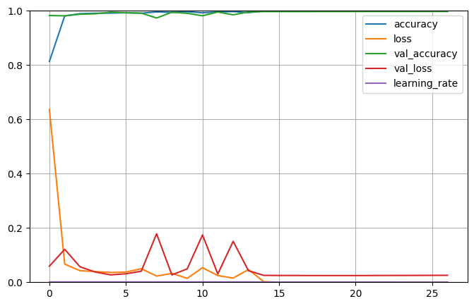

```python
pd.DataFrame(history.history).plot(figsize=(8,5))
plt.grid(True)
plt.gca().set_ylim(0, 1)
plt.show()
```

```python
total_loss, total_accuracy = final_model.evaluate(
    X_test_prepared,
    y_test
)

print(f"Total Loss: {total_loss}")
print(f"Total Accuracy: {total_accuracy}")
```

```
395/395 ━━━━━━━━━━━━━━━━━━━━ 6s 15ms/step - accuracy: 0.9763 - loss: 0.3032
Total Loss: 0.32394909858703613
Total Accuracy: 0.9752177596092224
```

## **Final Evaluation**

The tuned final model was evaluated on the test set, achieving improved accuracy compared to the initial version, demonstrating the effectiveness of hyperparameter tuning and model refinement.